# Lab 3: Joining data frames

### Learning objectives:

- the pipe operator `%>%`
- joining data frames using `full_join()` and `inner_join()`
- filtering out rows with missing observations using `is.na()` function
- creating descriptive statistics table using `stargazer()`
- selecting columns using `select()`, `subset()`, or `[,]`
- saving data using `write_csv()`

### 0.Introduction

Let’s begin by reading in our AAPL and GE data.

```r
library(tidyverse)
library(lubridate)
aapl <- read_csv("https://query1.finance.yahoo.com/v7/finance/download/AAPL?period1=1&period2=2000000000&interval=1d&events=history",
                 col_types=cols(Date=col_date(),
                                `Adj Close`=col_double()))
ge <- read_csv("https://query1.finance.yahoo.com/v7/finance/download/GE?period1=1&period2=2000000000&interval=1d&events=history")
```

### 1. Using the pipe `%>%` operator

The pipe operator `%>%` takes output from preceding function and feeds it as input to the next function. For example, `df <- df %>% arrange(Date)` is equivalent to `df <- arrange(df, Date)`.

This is useful if we want to apply several functions in succession to a data frame. For example, when we load our `aapl` data we want to `arrange` the data frame, then `filter` it, then `rename` and `select` some variables. We can do this as follows.

```r
aapl <- aapl %>%
  arrange(Date) %>%
  filter(month(Date) !=lead(month(Date))) %>%
  rename(aapl=`Adj Close`) %>%
  select(Date, aapl)

ge <- ge %>%
  arrange(Date) %>%
  filter(month(Date) !=lead(month(Date))) %>%
  rename(ge=`Adj Close`) %>%
  select(Date, ge)
```

### 2. Joining data frames

```r
merged <- full_join(aapl, ge, by="Date")
merged <- arrange(merged, Date)
head(merged, n=3)
```

```
## # A tibble: 3 x 3
##   Date        aapl      ge
##   <date>     <dbl>   <dbl>
## 1 1970-01-30    NA 0.00212
## 2 1970-02-27    NA 0.00206
## 3 1970-03-31    NA 0.00217
```

How many observations should the merged data frame have? `full_join()` matches the rows that have the same date in each data frame. If dates are found in `ge` but not in `aapl` or vice versa, `full_join` keeps those observations in the merged data frame. It places `NAs` where it can’t find matches. Since all dates in `aapl` are also in `ge`, but not all dates in `ge` are in `aapl`, the number of observations should be equal to the number of observations in `ge`.

There are several different types of joins. They are summarized in the diagram below.

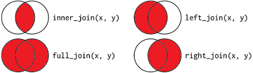

For example, if we wanted only observations that are in *both* `aapl` and `ge`, we could use `inner_join()`.

```r
merged <- inner_join(ge, aapl, by="Date")
merged <- arrange(merged, Date)
head(merged, n=3)
```

```
## # A tibble: 3 x 3
##   Date            ge  aapl
##   <date>       <dbl> <dbl>
## 1 1980-12-31 0.00540 0.483
## 2 1981-01-30 0.00540 0.400
## 3 1981-02-27 0.00589 0.375
```

Quick check: Which observations would we get if we ran `merged <- left_join(ge, aapl, by="Date")`?

What about `merged <- left_join(aapl, ge, by="Date")`?

Now that we have both GE and AAPL in one data frame we can plot them together.

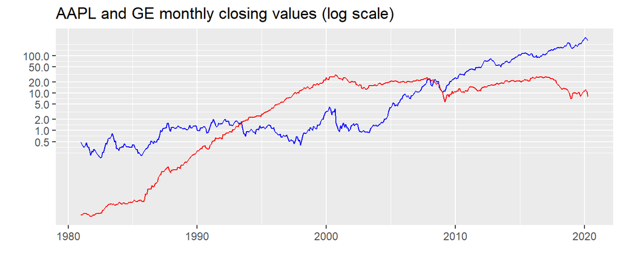

```r
ggplot(merged, aes(x=Date)) +
  geom_line(aes(y=aapl), color="blue") +
  geom_line(aes(y=ge), color="red") +
  scale_y_continuous(trans="log", breaks=c(0.5,1,2,5,10,20,50,100)) +
  labs(title="AAPL and GE monthly closing values (log scale)") + ylab("") + xlab("")
```

### 3. Filtering out rows with missing observations using `is.na()` function

```r
merged <- full_join(aapl, ge, by="Date")
merged <- filter(merged, is.na(aapl) == FALSE)
```

### IN-CLASS EXERCISE

1. Load in the NHL data on games and results, and NHL data on arenas. What is the number of observations in each data frame?

```r
nhl <- read_csv("https://dvorakt.github.io/business_analytics/lab1/NHLseason2016.csv")
arenas <- read_csv("https://dvorakt.github.io/business_analytics/lab3/NHLarenas.csv")
```

2. Are all teams in `arenas` also in `nhl`? Are all teams in `nhl` also in `arenas`?
3. What would be the best way to join the two data frames? Which variable should be the “by” variable?
4. Calculate percent occupancy for each game (i.e. attendance/capacity).

### 4. Creating a descriptive statistics table

```r
merged <- merged %>%
  mutate(ge_ret = (ge - lag(ge))/lag(ge)*100,
         aapl_ret = (aapl - lag(aapl))/lag(aapl)*100)
```

We can either use the base R function `summary()` or function `stargazer()` from a package of the same name. The `stargazer()` produces tables that are somewhat more readable. You can read about `stargazer`’s capabilities [here](https://www.jakeruss.com/cheatsheets/stargazer/). Stargazer works best with data frames that are explicitly declared as data frames, so we declare our tibble a data frame.

```r
library(stargazer)
merged <- as.data.frame(merged)
stargazer(merged, type="text", median=TRUE)
```

```
##
## ======================================================================
## Statistic  N   Mean  St. Dev.   Min   Pctl(25) Median Pctl(75)   Max
## ----------------------------------------------------------------------
## aapl      472 30.744  56.879   0.180   0.912   1.465   31.357  308.777
## ge        472 10.806  9.283    0.005   0.376   11.185  19.479  30.299
## ge_ret    471 1.913   8.499   -27.697  -2.555  0.971   6.107   42.119
## aapl_ret  471 2.213   13.100  -57.744  -5.759  2.028   9.844   45.378
## ----------------------------------------------------------------------
```

### 5. Selecting columns using `select()`, `subset()`, or `[,]`

In the above table, we are not interested in the descriptive statistics of the level of stock prices. We should tell stargazer to use only the two columns with returns. We can do that in a number of ways: using function `select()`, using base function `subset()`, or using `[,]` which allow us to identify which rows and columns we want to use. Notice we nest these functions inside the `stargazer()` function.

```r
stargazer(select(merged, ge_ret,aapl_ret), type="text", median=TRUE)
```

```
##
## ====================================================================
## Statistic  N  Mean  St. Dev.   Min   Pctl(25) Median Pctl(75)  Max
## --------------------------------------------------------------------
## ge_ret    471 1.913  8.499   -27.697  -2.555  0.971   6.107   42.119
## aapl_ret  471 2.213  13.100  -57.744  -5.759  2.028   9.844   45.378
## --------------------------------------------------------------------
```

```r
stargazer(subset(merged, select=c("ge_ret","aapl_ret")), type="text", median=TRUE)
```

```
##
## ====================================================================
## Statistic  N  Mean  St. Dev.   Min   Pctl(25) Median Pctl(75)  Max
## --------------------------------------------------------------------
## ge_ret    471 1.913  8.499   -27.697  -2.555  0.971   6.107   42.119
## aapl_ret  471 2.213  13.100  -57.744  -5.759  2.028   9.844   45.378
## --------------------------------------------------------------------
```

```r
stargazer(merged[,c("ge_ret","aapl_ret")], type="text", median=TRUE)
```

```
##
## ====================================================================
## Statistic  N  Mean  St. Dev.   Min   Pctl(25) Median Pctl(75)  Max
## --------------------------------------------------------------------
## ge_ret    471 1.913  8.499   -27.697  -2.555  0.971   6.107   42.119
## aapl_ret  471 2.213  13.100  -57.744  -5.759  2.028   9.844   45.378
## --------------------------------------------------------------------
```

Let’s also calculate the correlation coefficient between the returns on the two stocks.

```r
cor(merged$ge_ret, merged$aapl_ret, use = "complete.obs")
```

```
## [1] 0.2062468
```

### 6. Saving data using `write_csv()`

We did some data manipulation and created new data sets that we may want to use in the next lab. Let’s save the data so that we don’t have to redo all of that manipulation. We’ll use function `write_csv()` which takes as arguments the data frame to be saved and the name of the new .csv file. If you don’t include a full path, the file will be saved in your working directory. To see what is your working directory type `getwd()` in the console. If you are working within an R Studio `project`, the working directory is the `project’ directory.

```r
write_csv(merged, "GE_AAPL_monthly.csv")
write_csv(nhl, "NHLseason_with_arenas.csv")
```

### Exercises

1. Data on New York City weather in Nexus `lab data files` folder in `NYC_weather.csv`. Save the file to your `business analytics` folder. The data has information on daily precipitation (in tenths of millimeters) and min and max temperatures (in tenths of degree Celsius) as recorded by the Belevedere Tower in Central Park. The data comes from http://www.ncdc.noaa.gov. Note that missing values are indicated as -9999. Load the data into R.
2. Summarize the variables. Are the values reasonable? Are there any missing values? If so, drop the observations that have missing values. How many observations did you lose by dropping these?
3. Change the `DATE` variable from a ‘numeric’ type to ‘Date’ type. (Hint 1: `as.Date()` does not work on numeric, so you first need to turn `DATE` into character using `as.character()` Hint 2: Note also that the format of the date is “%Y%m%d” i.e. no dashes between year, month and day.)
4. Plot the minimum and maximum temperatures on a time line for the entire period. Then do the same since 2014.
5. Load in the daily data on Dow Jones Industrial from Nexus. The file is called `dji.csv`. Calculate daily returns. Check the descriptive stats of your daily return.
6. Merge your daily DJI data with your NYC weather data. Keep only dates that are in both data sets. Which observations do you lose from either data set?
7. What is the correlation between temperature and returns?
8. Save the merged data into a .csv file. Make sure that you are in your business analytics `project` so that R knows to save into that folder.